# notebook

The Nobel Prize has been among the most prestigious international awards since 1901. Each year, awards are bestowed in chemistry, literature, physics, physiology or medicine, economics, and peace. In addition to the honor, prestige, and substantial prize money, the recipient also gets a gold medal with an image of Alfred Nobel (1833 - 1896), who established the prize.

[figure not shown]

The Nobel Foundation has made a dataset available of all prize winners from the outset of the awards from 1901 to 2023. The dataset used in this project is from the Nobel Prize API and is available in the `nobel.csv` file in the `data` folder.

In this project, you'll get a chance to explore and answer several questions related to this prizewinning data. And we encourage you then to explore further questions that you're interested in!

```python
# Loading in required libraries
import pandas as pd
import seaborn as sns
import numpy as np

# Start coding here!
```

## 1 Load the dataset and find the most common gender and birth country

```python
#Load the dataset into a DataFrame using pandas
nobel = pd.read_csv('data/nobel.csv')
#extract the top values from sex and birth_country
top_gender = nobel['sex'].value_counts().index[0]
top_country = nobel['birth_country'].value_counts().index[0]
print("\n The gender with the most Nobel laureates is :", top_gender)
print(" The most common birth country of Nobel laureates is :", top_country)
```

```
 The gender with the most Nobel laureates is : Male
 The most common birth country of Nobel laureates is : United States of America
```

## 2. Identify the decade with the highest proportion of US-born winners

```python
#create a column that creates a flag for winners whose birth country is "United States of America"
nobel['winners_us'] = nobel['birth_country'] == 'United States of America'
```

```python
#create a decade column
nobel['decade'] = (np.floor(nobel['year'] / 10) * 10).astype(int)
```

```python
#find the proportion
proportion_win_us = nobel.groupby('decade', as_index=False)['winners_us'].mean()
print(proportion_win_us)
```

```
    decade  winners_us
0     1900    0.017544
1     1910    0.075000
2     1920    0.074074
3     1930    0.250000
4     1940    0.302326
5     1950    0.291667
6     1960    0.265823
7     1970    0.317308
8     1980    0.319588
9     1990    0.403846
10    2000    0.422764
11    2010    0.314050
12    2020    0.360000
```

```python
#Identify the decade with the highest proportion of US-born winners
max_decade_usa = proportion_win_us[proportion_win_us['winners_us'] == proportion_win_us['winners_us'].max()]['decade'].values[0]

print(max_decade_usa)
```

```
2000
```

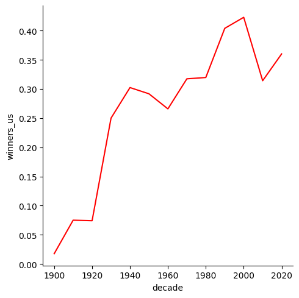

```python
#Create a relational line plot
import matplotlib.pyplot as plt

ax1 = sns.relplot(x='decade', y='winners_us', data=proportion_win_us, kind='line', color='r')
plt.show()
```

## 3. Find the decade and category with the highest proportion of female laureates

```python
#proportion of female winners
nobel['female_winners'] = nobel['sex']=='Female'

prop_female_winners = nobel.groupby(['decade', 'category'], as_index=False)['female_winners'].mean()

print(prop_female_winners)
```

```
    decade    category  female_winners
0     1900   Chemistry        0.000000
1     1900  Literature        0.100000
2     1900    Medicine        0.000000
3     1900       Peace        0.071429
4     1900     Physics        0.076923
..     ...         ...             ...
67    2020   Economics        0.111111
68    2020  Literature        0.500000
69    2020    Medicine        0.125000
70    2020       Peace        0.285714
71    2020     Physics        0.166667

[72 rows x 3 columns]
```

```python
#Find the decade and category with the highest female winners
max_female_decade_category = prop_female_winners[prop_female_winners['female_winners'] == prop_female_winners['female_winners'].max()][['decade', 'category']]
print(max_female_decade_category)
```

```
    decade    category
68    2020  Literature
```

```python
# Create a dictionary
max_female_dict = {max_female_decade_category['decade'].values[0]: max_female_decade_category['category'].values[0]}
```

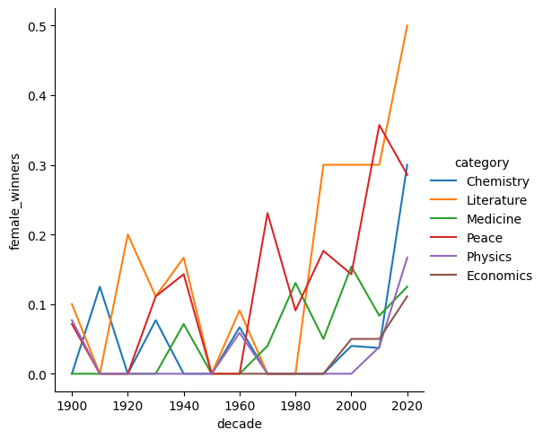

```python
#Create a relational line plot with multiple categories
ax2 = sns.relplot(x='decade', y='female_winners', data=prop_female_winners, hue='category', kind='line')
```

## 4. Find first woman to win a Nobel Prize

```python
nobel_women = nobel[nobel['female_winners']]
min_row = nobel_women[nobel_women['year'] == nobel_women['year'].min()]
first_woman_name = min_row['full_name'].values[0]
first_woman_category = min_row['category'].values[0]
print(f"\n The first woman to win a Nobel Prize was {first_woman_name}, in the category of {first_woman_category}.")
```

```
 The first woman to win a Nobel Prize was Marie Curie, née Sklodowska, in the category of Physics.
```

## 5. Determine repeat winners

```python
#Count the values in a column
winners = nobel['full_name'].value_counts()
repeats = winners[winners >= 2].index
repeat_list = list(repeats)
print(repeat_list)
```

```
['Comité international de la Croix Rouge (International Committee of the Red Cross)', 'Linus Carl Pauling', 'John Bardeen', 'Frederick Sanger', 'Marie Curie, née Sklodowska', 'Office of the United Nations High Commissioner for Refugees (UNHCR)']
```